DS 6030 | Fall 2024 | University of Virginia

# Homework #10: Density Estimation

Author

**Benton Pelczynski**

Published

November 25, 2024

# Required R packages and Directories

```r
data_dir = 'https://mdporter.github.io/teaching/data' # data directory
library(ks)        # functions for KDE
library(tidyverse) # functions for data manipulation
```

# Problem 1 Geographic Profiling

Geographic profiling, a method developed in criminology, can be used to estimate the [home location (roost) of animals](https://www.sciencedirect.com/science/article/pii/S0022519305004157) based on a collection of sightings. The approach requires an estimate of the distribution the animal will travel from their roost to forage for food.

A sample of $283$ distances that pipistrelle bats traveled (in meters) from their roost can be found at:

- **Bat Data**: <https://mdporter.github.io/teaching/data/geo_profile.csv>

One probability model for the distance these bats will travel is:
$$\begin{align*}
f(x; \theta) = \frac{x}{\theta} \exp \left( - \frac{x^2}{2 \theta} \right)
\end{align*}$$
where the parameter $\theta > 0$ controls how far they are willing to travel.

## a. Derive a closed-form expression for the MLE for $\theta$ (i.e., show the math).

**Solution**

$L(\theta)=\prod^{n}_{i=1}f(x_i;\theta)=\prod^{n}_{i=1}\frac{x_i}{\theta}exp(-\frac{x^2_i}{2\theta})$

$L(\theta)=(\frac{1}{\theta})^n\prod^{n}_{i=1}x_i\cdot\prod^{n}_{i=1}exp(-\frac{x^2_i}{2\theta})=(\frac{1}{\theta})^n\prod^{n}_{i=1}x_i\cdot exp(-\frac{\sum^{n}_{i=1}x^2_i}{2\theta})$

$logL(\theta)=-nlog\theta+\sum^{n}_{i=1}logx_i-\frac{\sum^{n}_{i=1}x^2_i}{2\theta}$

$\frac{dlogL(\theta)}{d\theta}=\frac{-n}{\theta}+\frac{\sum^{n}_{i=1}x^2_i}{2\theta^2}$

$\frac{-n}{\theta}+\frac{\sum^{n}_{i=1}x^2_i}{2\theta^2}=0$

$-n\theta+\frac{\sum^{n}_{i=1}x^2_i}{2}=0$

$\frac{\sum^{n}_{i=1}x^2_i}{2}=n\theta$

$\frac{\sum^{n}_{i=1}x^2_i}{2n}=\theta$

## b. Estimate $\theta$ for the bat data using MLE?

Calculate using the solution to part a, or use computational methods.

**Solution**

```r
bat = read.csv("geo_profile.csv", header = FALSE)

theta = sum(bat$V1^2)/566
theta
```

```
[1] 4.52
```

## c. Plot the estimated density

Using the MLE value of $\theta$ from part b, calculate the estimated density at a set of evaluation points between 0 and 8 meters. Plot the estimated density.

- The x-axis should be distance and y-axis should be density (pdf).

**Solution**

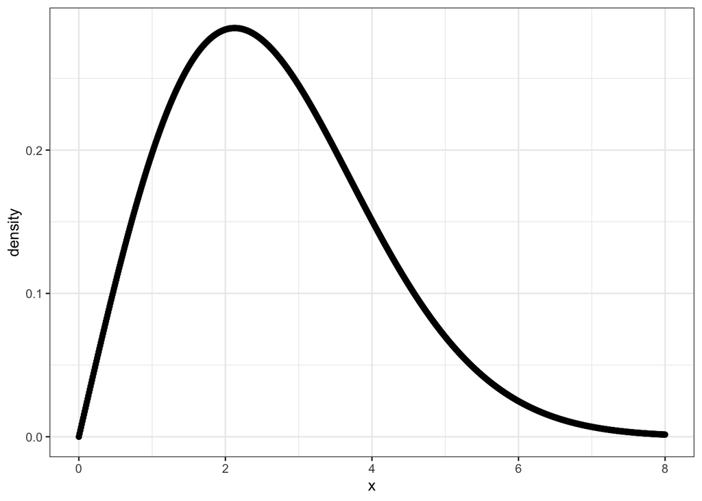

```r
eval = tibble(x = seq(0, 8, by=0.01))
eval = eval %>% mutate(density = (eval$x/theta)*exp(-(eval$x^2)/(2*theta)))

ggplot(eval, aes(x=x, y=density)) + geom_point()
```

## d. Estimate the density using KDE.

Report the bandwidth you selected and produce a plot of the estimated density.

**Solution**

```r
bat.kde = kde(bat$V1)

bat.kde$h
```

```
[1] 0.391
```

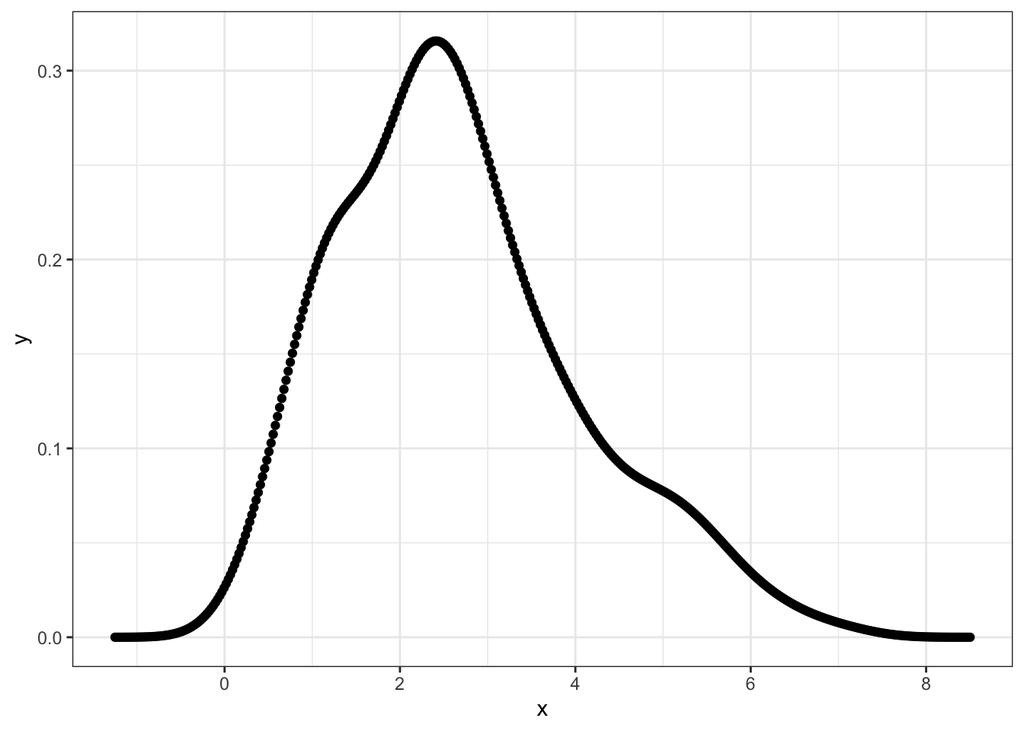

```r
tibble(x = bat.kde$eval.points, y=bat.kde$estimate) %>%
ggplot(aes(x,y)) + geom_point()
```

## e. Which model do you prefer, the parametric or KDE? Why?

**Solution**

I prefer KDE as model for estimating the distance distribution. While the parametric model is smoother and easier to use, the fact that it is based on an assumed distribution suggests it may be oversmoothed. On the other hand, the bat data has a large enough sample size that we can expect the KDE model to be more accurate to the actual distribution. That said, the models are similar enough to where I would expect their performance to generally be about the same.

# Problem 2: Interstate Crash Density

Interstate 64 (I-64) is a major east-west road that passes just south of Charlottesville. Where and when are the most dangerous places/times to be on I-64? The crash data (link below) gives the mile marker and fractional time-of-week for crashes that occurred on I-64 between mile marker 87 and 136 in 2016. The time-of-week data takes a numeric value of *<dow>.<hour/24>*, where the dow starts at 0 for Sunday (6 for Sat) and the decimal gives the time of day information. Thus `time=0.0417` corresponds to Sun at 1am and `time=6.5` corresponds to Sat at noon.

- **Crash Data**: <https://mdporter.github.io/teaching/data/crashes16.csv>

## a. Crash Data

Extract the crashes and make a scatter plot with mile marker on x-axis and time on y-axis.

**Solution**

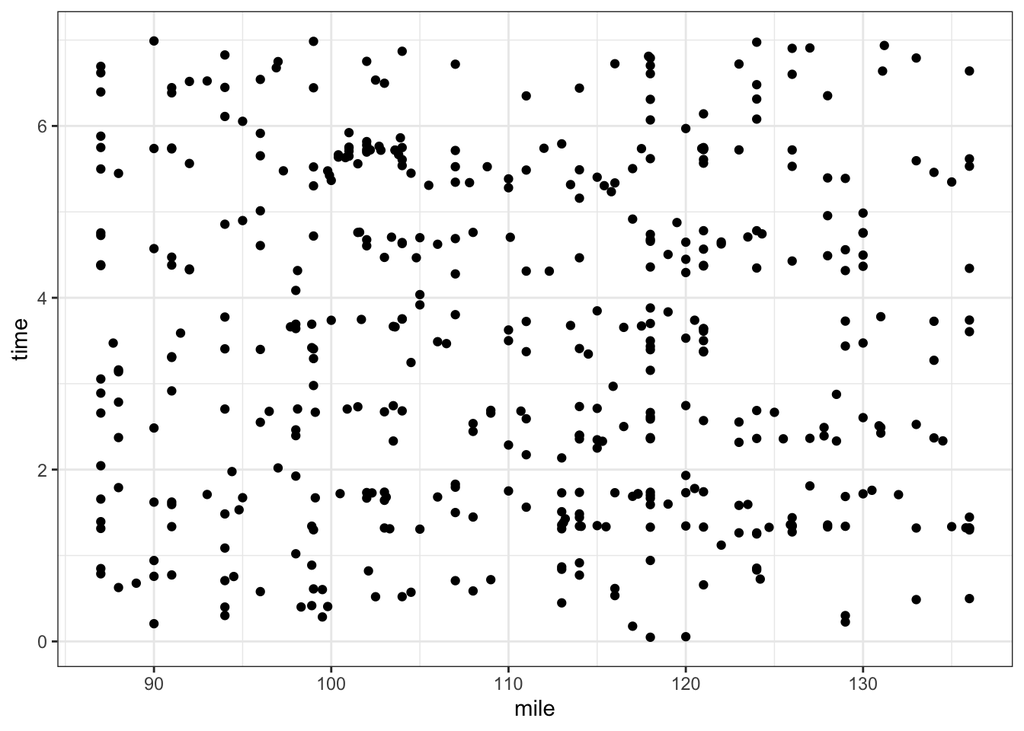

```r
crash = read.csv("crashes16.csv")

ggplot(crash, aes(mile, time)) + geom_point()
```

## b. Use KDE to estimate the *mile marker* density.

- Report the bandwidth.
- Plot the density estimate.

**Solution**

```r
mile.kde = kde(crash$mile)

mile.kde$h
```

```
[1] 2.89
```

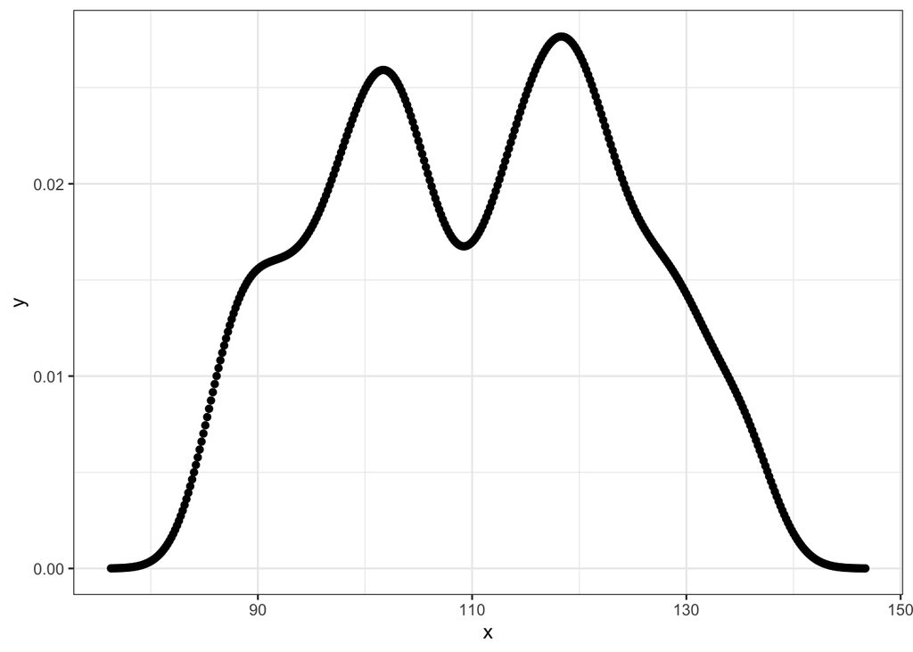

```r
tibble(x = mile.kde$eval.points, y=mile.kde$estimate) %>%
ggplot(aes(x,y)) + geom_point()
```

## c. Use KDE to estimate the temporal *time-of-week* density.

- Report the bandwidth.
- Plot the density estimate.

**Solution**

```r
time.kde = kde(crash$time)

time.kde$h
```

```
[1] 0.414
```

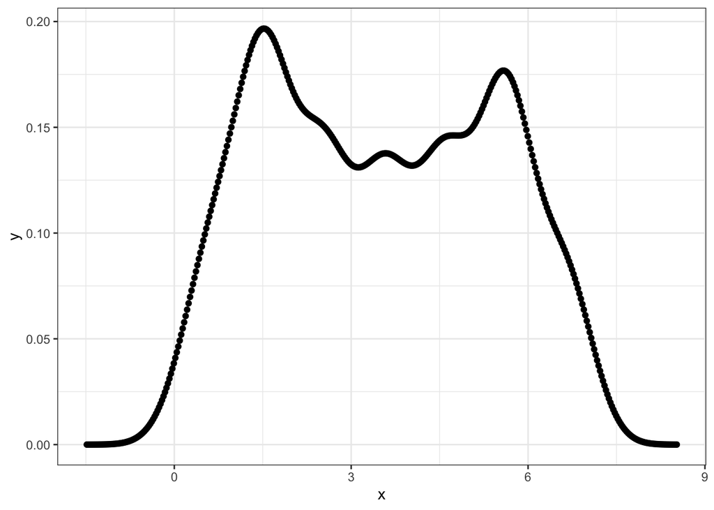

```r
tibble(x = time.kde$eval.points, y=time.kde$estimate) %>%
ggplot(aes(x,y)) + geom_point()
```

## d. Use KDE to estimate the bivariate mile-time density.

- Report the bandwidth parameters.
- Plot the bivariate density estimate.

**Solution**

```r
miletime.kde = kde(crash)

miletime.kde$H
```

```
       [,1]   [,2]
[1,] 19.045 -0.115
[2,] -0.115  0.330
```

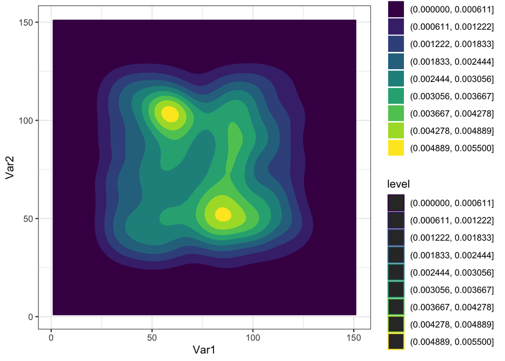

```r
ggplot(reshape2::melt(miletime.kde$estimate)) +
  geom_contour_filled(aes(x = Var1, y = Var2, z = value, color = stat(level)),
               bins = 9)
```

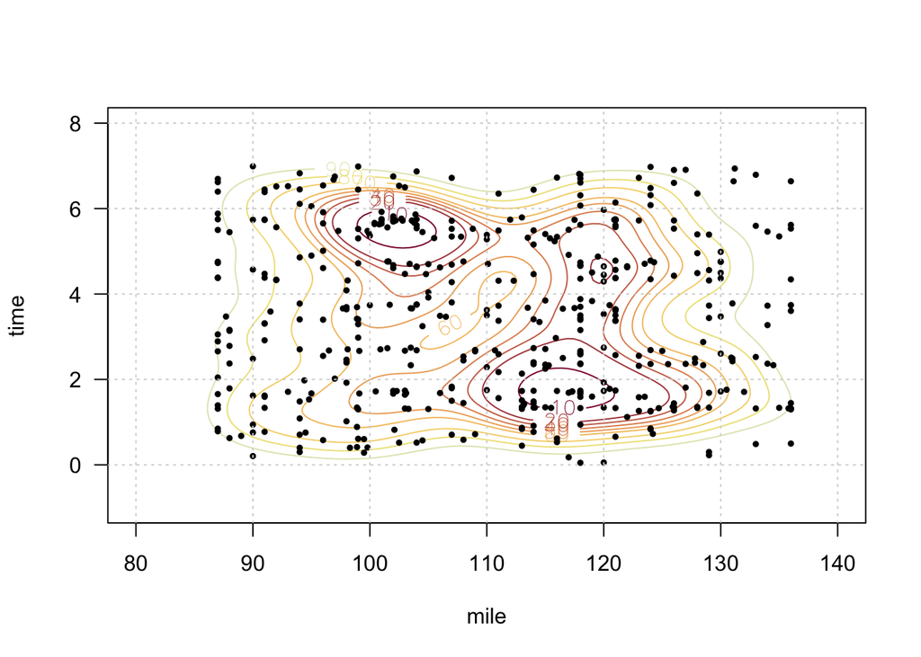

```r
plot(miletime.kde,
cont = c(10, 20, 30, 40, 50, 60, 70, 80, 90),
las=1, xlim = c(80, 140), ylim=c(-1, 8))
points(crash, pch=19, cex=.5)
grid()
```

## e. Crash Hotspot

Based on the estimated density, approximate the most dangerous place and time to drive on this stretch of road. Identify the mile marker and time-of-week pair (within a few miles and hours).